# An Introduction to **corrplot** package

## Introduction

The **corrplot** package is a graphical display of a correlation matrix, confidence interval.  
It also contains some algorithms to do matrix reordering. In addition, corrplot is good at details, including choosing color, text labels, color labels, layout, etc.

## Visualization Methods

There are seven visualization methods (parameter `method`) in **corrplot** package, named `"circle"`, `"square"`, `"ellipse"`, `"number"`, `"shade"`, `"color"`, `"pie"`.

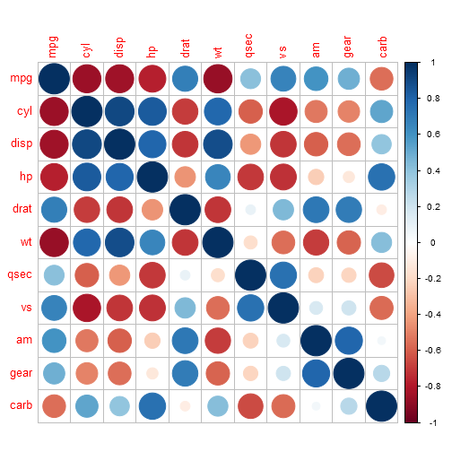

```r
data(mtcars)
M <- cor(mtcars)
corrplot(M, method = "circle")
```

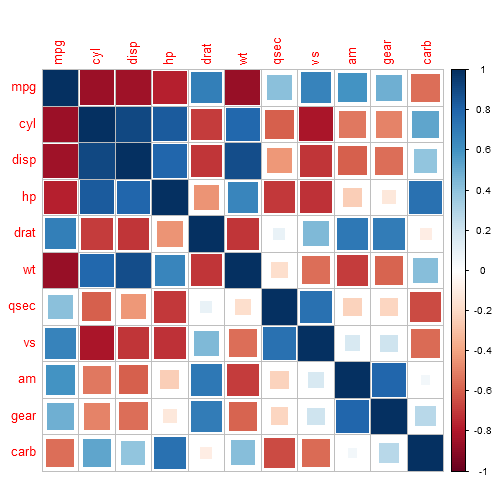

```r
corrplot(M, method = "square")
```

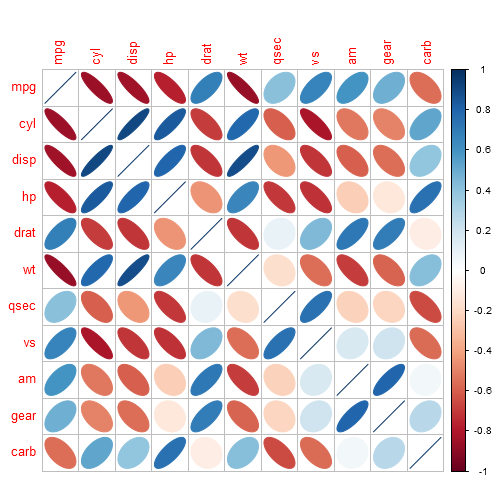

```r
corrplot(M, method = "ellipse")
```

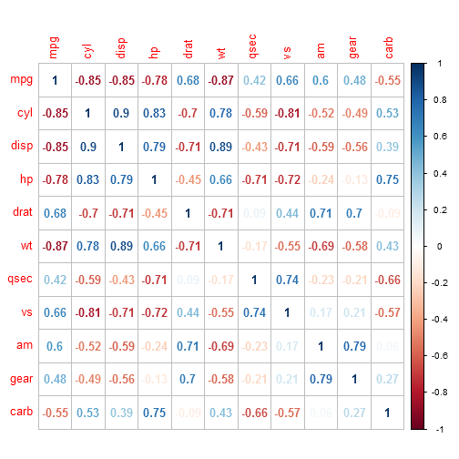

```r
corrplot(M, method = "number")
```

[figure not shown]

```r
corrplot(M, method = "shade")
```

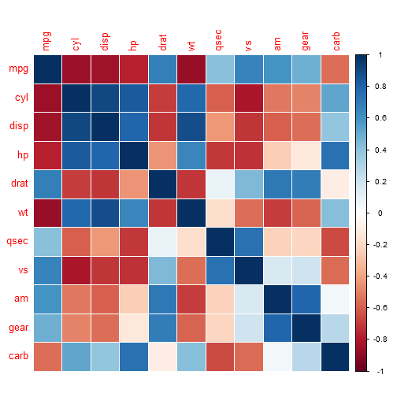

```r
corrplot(M, method = "color")
```

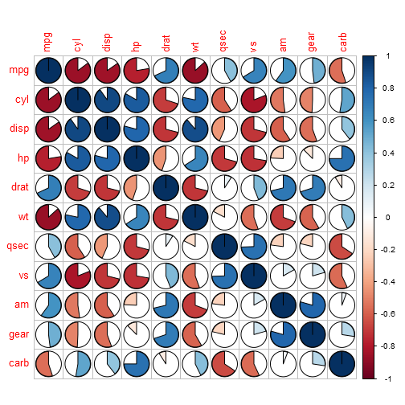

```r
corrplot(M, method = "pie")
```

## Layout

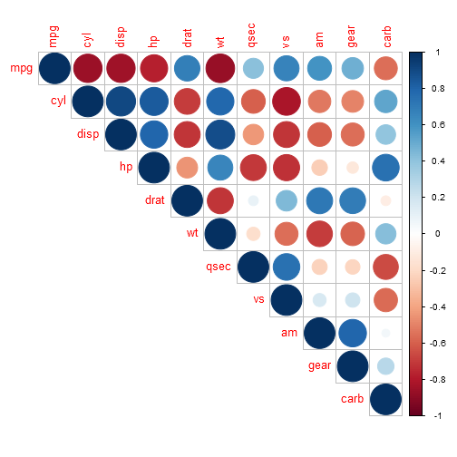

```r
corrplot(M, type = "upper")
```

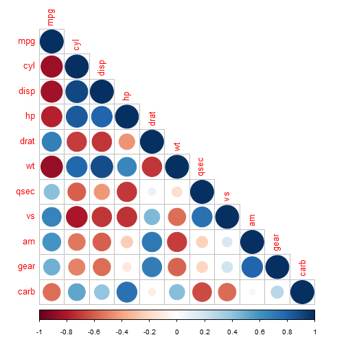

```r
corrplot(M, type = "lower")
```

`corrplot.mixed()` is a wrapped function for mixed visualization style.

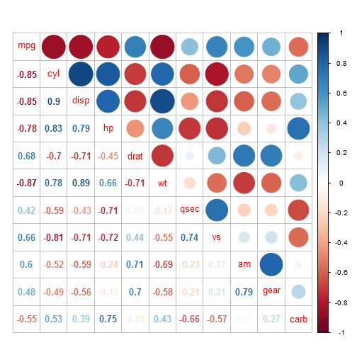

```r
corrplot.mixed(M)
```

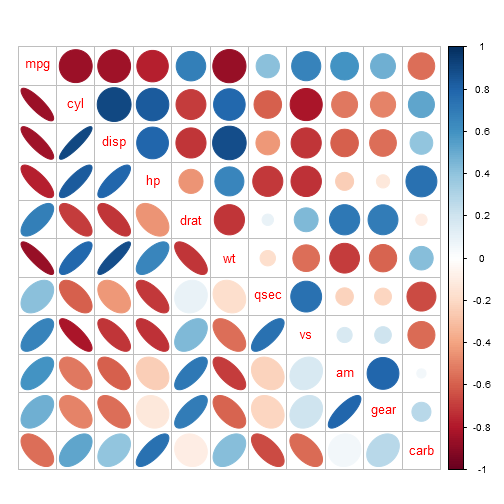

```r
corrplot.mixed(M, lower = "ellipse", upper = "circle")
```

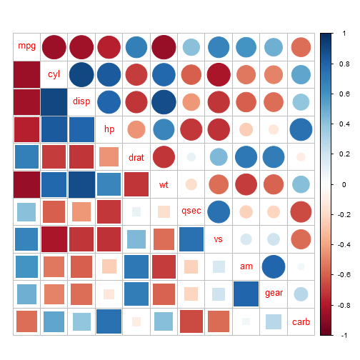

```r
corrplot.mixed(M, lower = "square", upper = "circle")
```

## Reorder A Correlation Matrix

Matrix reorder is very important for mining the hiden structure and pattern in the matrix. There are four methods in corrplot (parameter `order`), named `"AOE"`, `"FPC"`, `"hclust"`, `"alphabet"`. More algorithms can be found in seriation package.

You can also reorder the matrix “manually” via function `corrMatOrder()`.

- `"AOE"` is for the angular order of the eigenvectors. It is calculated from the order of the angles. \( a_i \),

\[ a_i = \begin{cases} \tan (e_{i2}/e_{i1}), & \text{if $e_{i1}>0$;} \newline \tan (e_{i2}/e_{i1}) + \pi, & \text{otherwise.} \end{cases} \]

where \( e_1 \) and \( e_2 \) are the largest two eigenvalues of the correlation matrix. See Michael Friendly (2002) for details.

- `"FPC"` for the first principal component order.
- `"hclust"` for hierarchical clustering order, and `"hclust.method"` for the agglomeration method to be used . `"hclust.method"` should be one of `"ward"`, `"single"`, `"complete"`, `"average"`, `"mcquitty"`, `"median"` or `"centroid"`.
- `"alphabet"` for alphabetical order.

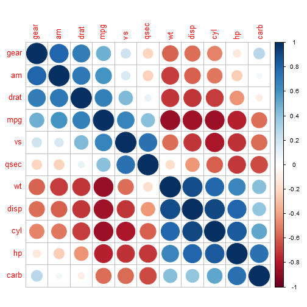

```r
corrplot(M, order = "AOE")
```

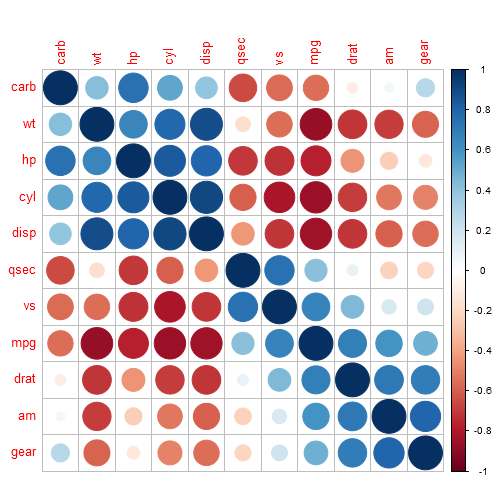

```r
corrplot(M, order = "hclust")
```

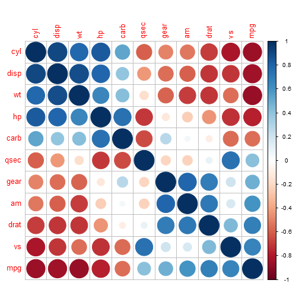

```r
corrplot(M, order = "FPC")
```

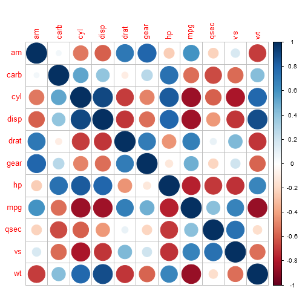

```r
corrplot(M, order = "alphabet")
```

If using `"hclust"`, `corrplot()` can draw rectangles around the chart of corrrlation matrix based on the results of hierarchical clustering.

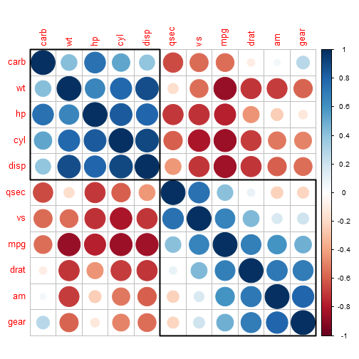

```r
corrplot(M, order = "hclust", addrect = 2)
```

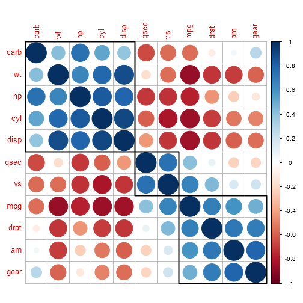

```r
corrplot(M, order = "hclust", addrect = 3)
```

## Using Different Color Spectrum

We can also specify the color system, `colorRampPalette()` is very convenient for generating color spectrum.

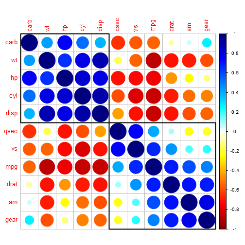

```r
col1 <- colorRampPalette(c("#7F0000", "red", "#FF7F00", "yellow", "white", "cyan",
    "#007FFF", "blue", "#00007F"))
col2 <- colorRampPalette(c("#67001F", "#B2182B", "#D6604D", "#F4A582", "#FDDBC7",
    "#FFFFFF", "#D1E5F0", "#92C5DE", "#4393C3", "#2166AC", "#053061"))
col3 <- colorRampPalette(c("red", "white", "blue"))
col4 <- colorRampPalette(c("#7F0000", "red", "#FF7F00", "yellow", "#7FFF7F",
    "cyan", "#007FFF", "blue", "#00007F"))
wb <- c("white", "black")
## using these color spectrums
corrplot(M, order = "hclust", addrect = 2, col = col1(100))
```

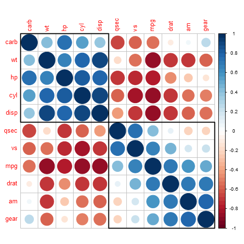

```r
corrplot(M, order = "hclust", addrect = 2, col = col2(50))
```

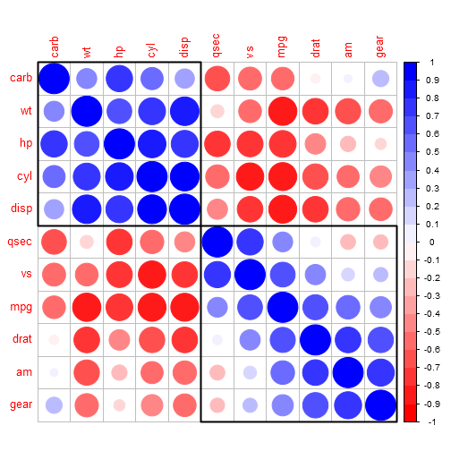

```r
corrplot(M, order = "hclust", addrect = 2, col = col3(20))
```

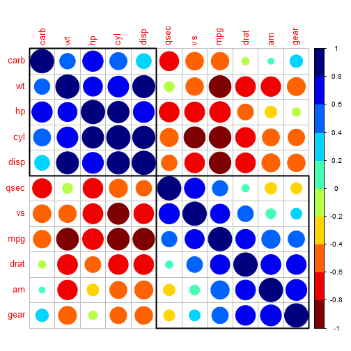

```r
corrplot(M, order = "hclust", addrect = 2, col = col4(10))
```

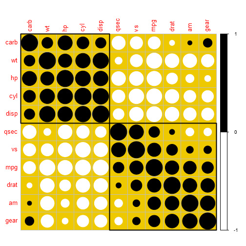

```r
corrplot(M, order = "hclust", addrect = 2, col = wb, bg = "gold2")
```

## Color Legend and Text Legend

Parameter `cl.*` is for color legend, and `tl.*` if for text legend.

Here are some examples.

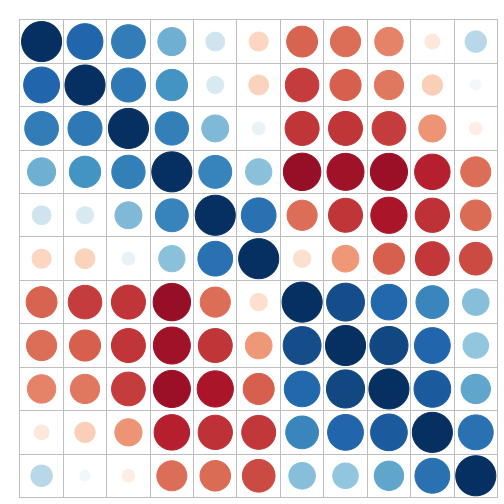

```r
## remove color legend and text legend
corrplot(M, order = "AOE", cl.pos = "n", tl.pos = "n")
```

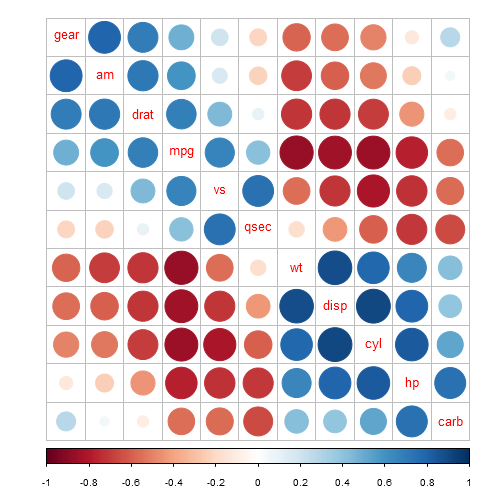

```r
## bottom color legend, diagonal text legend, rotate text label
corrplot(M, order = "AOE", cl.pos = "b", tl.pos = "d", tl.srt = 60)
```

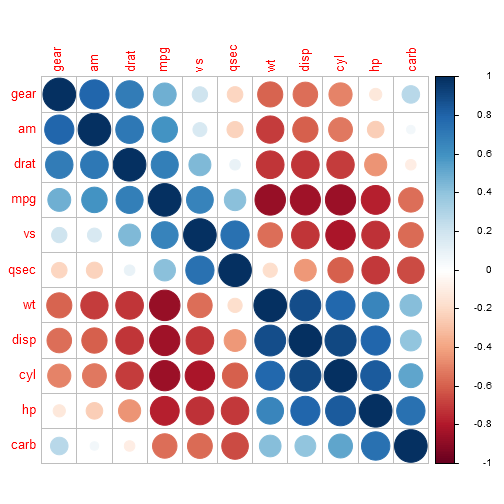

```r
## a wider color legend with numbers right aligned
corrplot(M, order = "AOE", cl.ratio = 0.2, cl.align = "r")
```

## Deal with the Non-correlation Matrix

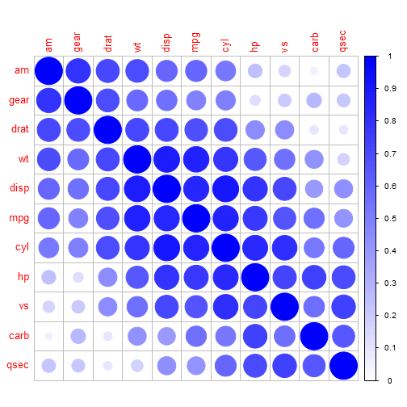

```r
corrplot(abs(M), order = "AOE", col = col3(200), cl.lim = c(0, 1))
```

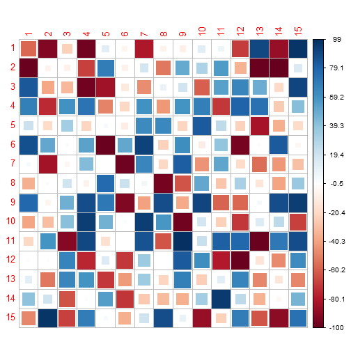

```r
## visualize a matrix in [-100, 100]
ran <- round(matrix(runif(225, -100, 100), 15))
corrplot(ran, is.corr = FALSE, method = "square")
```

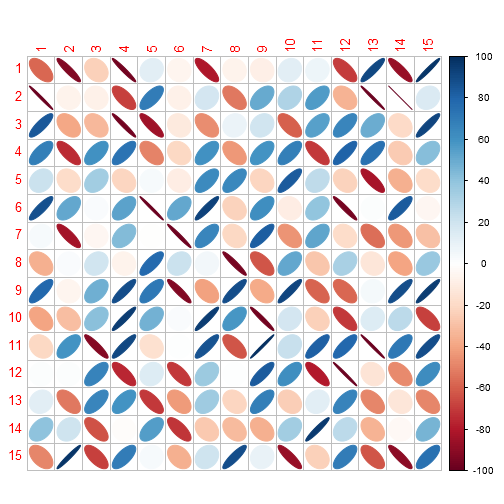

```r
## a beautiful color legend
corrplot(ran, is.corr = FALSE, method = "ellipse", cl.lim = c(-100, 100))
```